# PRODUISEZ UNE ETUDE DE MARCHE

## Objectif de ce NOTEBOOK

Société " La poule qui chante"c, une entreprise française d’agroalimentaire souhaite trouver des nouveaux marchés à l'exportation.

--PARTIE 2 - Analyse ACP

- Analyse ACP avec réductions des dimensions (variables).
- Analyse des cercles de corrélations et la projection des individus.

--PARTIE 3 - Clustering

- Regroupement en utilisant les données brutes.
- Classification ascendante hiérarchique puis k-means.

# PARTIE 2 - ANALYSE ACP

## Importation des librairies pour l'analyse.

```python
import pandas as pd
import numpy as np

from sklearn.decomposition import PCA
from sklearn.preprocessing import StandardScaler

import matplotlib.pyplot as plt
from matplotlib.collections import LineCollection

import seaborn as sns
```

On charge SEABORN

```python
sns.set()
```

## Chargement des données de l'étude de marché

```python
#On charge le fichier à analyser
analyse = pd.read_csv('OUT_merge_final_pour_ACP.csv', delimiter=',')
```

```python
analyse.info()
```

```
<class 'pandas.core.frame.DataFrame'>
RangeIndex: 100 entries, 0 to 99
Data columns (total 13 columns):
 #   Column                    Non-Null Count  Dtype
---  ------                    --------------  -----
 0   Zone                      100 non-null    object
 1   Population totale         100 non-null    float64
 2   pourcent_pop              100 non-null    float64
 3   Disponibilité intérieure  100 non-null    float64
 4   Exportations - Quantité   100 non-null    float64
 5   Importations - Quantité   100 non-null    float64
 6   Pertes                    100 non-null    float64
 7   Production                100 non-null    float64
 8   Importations bilatérales  100 non-null    float64
 9   Taux de douane            100 non-null    float64
 10  Taux de chomage           100 non-null    float64
 11  Indice penetration        100 non-null    float64
 12  niveau_revenu             100 non-null    object
dtypes: float64(11), object(2)
memory usage: 10.3+ KB
```

Pourcentage de valeurs manquantes par colonne

```python
analyse.isna().mean()
```

```
Zone                        0.0
Population totale           0.0
pourcent_pop                0.0
Disponibilité intérieure    0.0
Exportations - Quantité     0.0
Importations - Quantité     0.0
Pertes                      0.0
Production                  0.0
Importations bilatérales    0.0
Taux de douane              0.0
Taux de chomage             0.0
Indice penetration          0.0
niveau_revenu               0.0
dtype: float64
```

Est-ce qu'il y a des lignes en double ?

```python
analyse.duplicated().sum()
```

```
0
```

combine de valeurs différentes par colonne ?

```python
analyse.nunique()
```

```
Zone                        100
Population totale           100
pourcent_pop                100
Disponibilité intérieure     81
Exportations - Quantité      33
Importations - Quantité      54
Pertes                       29
Production                   77
Importations bilatérales     43
Taux de douane               51
Taux de chomage              85
Indice penetration           81
niveau_revenu                 4
dtype: int64
```

Vue sur la dispersion des données

```python
analyse.describe()
```

|  | Population totale | pourcent_pop | Disponibilité intérieure | Exportations - Quantité | Importations - Quantité | Pertes | Production | Importations bilatérales | Taux de douane | Taux de chomage | Indice penetration |
| --- | --- | --- | --- | --- | --- | --- | --- | --- | --- | --- | --- |
| count | 1.000000e+02 | 100.000000 | 1.000000e+02 | 1.000000e+02 | 1.000000e+02 | 100.000000 | 1.000000e+02 | 1.000000e+02 | 100.00000 | 100.000000 | 100.000000 |
| mean | 7.290277e+07 | 0.965838 | 6.403400e+05 | 1.181500e+05 | 1.059600e+05 | 21790.000000 | 6.708200e+05 | 6.396091e+06 | 9.35890 | 7.831913 | 9.686922 |
| std | 1.958363e+08 | 2.594500 | 1.234580e+06 | 4.687214e+05 | 2.075580e+05 | 79597.509605 | 1.574081e+06 | 2.842343e+07 | 11.75039 | 7.013111 | 13.317032 |
| min | 8.438036e+06 | 0.111790 | 0.000000e+00 | 0.000000e+00 | 0.000000e+00 | 0.000000 | 0.000000e+00 | 0.000000e+00 | 0.00000 | 0.000000 | 0.000000 |
| 25% | 1.204588e+07 | 0.159588 | 4.450000e+04 | 0.000000e+00 | 0.000000e+00 | 0.000000 | 1.900000e+04 | 0.000000e+00 | 0.00000 | 2.791583 | 1.356539 |
| 50% | 2.660160e+07 | 0.352426 | 1.935000e+05 | 0.000000e+00 | 1.100000e+04 | 0.000000 | 1.390000e+05 | 0.000000e+00 | 7.21500 | 5.829667 | 3.628076 |
| 75% | 5.370198e+07 | 0.711460 | 9.130000e+05 | 2.400000e+04 | 1.100000e+05 | 5500.000000 | 9.635000e+05 | 6.403369e+05 | 15.82000 | 12.385333 | 13.975934 |
| max | 1.421022e+09 | 18.826133 | 9.982000e+06 | 4.223000e+06 | 1.069000e+06 | 695000.000000 | 1.420100e+07 | 2.423373e+08 | 62.98000 | 29.326667 | 60.764504 |

```python
# on arrondi tous les nombres avec deux chiffres après la virgule
analyse = analyse.round(2)
```

Dimension du datframe

```python
analyse.shape
```

```
(100, 13)
```

```python
# on définit la colonne 'Zone' comme index du datframe
analyse2 = analyse.set_index('Zone')
analyse2 = analyse2.drop(columns="niveau_revenu")

# copie la matrice de donnéee dans un tableau numpy
X = analyse2.values

# affichage des 5 premières lignes du tableau
X[:5]
```

```
array([[3.62961130e+07, 4.80000000e-01, 5.70000000e+04, 0.00000000e+00,
        2.90000000e+04, 2.00000000e+03, 2.80000000e+04, 0.00000000e+00,
        0.00000000e+00, 1.22300000e+01, 3.62000000e+00],
       [5.70097560e+07, 7.60000000e-01, 2.11800000e+06, 6.30000000e+04,
        5.14000000e+05, 8.30000000e+04, 1.66700000e+06, 4.68966663e+06,
        8.54000000e+00, 2.93300000e+01, 1.81800000e+01],
       [4.13891890e+07, 5.50000000e-01, 2.77000000e+05, 0.00000000e+00,
        2.00000000e+03, 1.30000000e+04, 2.75000000e+05, 0.00000000e+00,
        2.33900000e+01, 1.72100000e+01, 1.99000000e+00],
       [8.26584090e+07, 1.10000000e+00, 1.73900000e+06, 6.46000000e+05,
        8.42000000e+05, 0.00000000e+00, 1.51400000e+06, 0.00000000e+00,
        0.00000000e+00, 4.64000000e+00, 5.17500000e+01],
       [2.98167660e+07, 4.00000000e-01, 3.19000000e+05, 0.00000000e+00,
        2.77000000e+05, 2.00000000e+03, 4.20000000e+04, 2.04400378e+06,
        0.00000000e+00, 2.03600000e+01, 3.78000000e+00]])
```

le dataframe est bien dans un tableau numpy

```python
type(X)
```

```
numpy.ndarray
```

La forme de la matrice correspond à notre dataframe sans les deux colonnes avec des variable qualitatives

```python
X.shape
```

```
(100, 11)
```

On sauvegarde la liste des pays dans une variable 'pays'

```python
pays = analyse2.index
pays
```

```
Index(['Afghanistan', 'Afrique du Sud', 'Algérie', 'Allemagne', 'Angola',
       'Arabie saoudite', 'Argentine', 'Australie', 'Autriche', 'Azerbaïdjan',
       'Bangladesh', 'Belgique', 'Bolivie', 'Brésil', 'Burkina Faso',
       'Burundi', 'Bélarus', 'Bénin', 'Cambodge', 'Cameroun', 'Canada',
       'Chili', 'Taïwan (République de Chine)', 'Chine', 'Colombie', 'Cuba',
       'Côte d'Ivoire', 'Espagne', 'France', 'Russie', 'Ghana', 'Grèce',
       'Guatemala', 'Guinée', 'Haïti', 'Honduras', 'Hongrie', 'Inde',
       'Indonésie', 'Irak', 'Iran', 'Italie', 'Japon', 'Jordanie',
       'Kazakhstan', 'Kenya', 'Madagascar', 'Malaisie', 'Malawi', 'Mali',
       'Maroc', 'Mexique', 'Mozambique', 'Myanmar', 'Niger', 'Nigéria',
       'Népal', 'Ouganda', 'Ouzbékistan', 'Pakistan',
       'Papouasie-Nouvelle-Guinée', 'Pays-Bas', 'Philippines', 'Pologne',
       'Portugal', 'Pérou', 'Roumanie', 'Royaume-Uni', 'Rwanda', 'Syrie',
       'Corée du Sud', 'République dominicaine',
       'République démocratique du Congo', 'Corée du Nord', 'Tanzanie',
       'Serbie', 'Somalie', 'Soudan', 'Soudan du Sud', 'Sri Lanka', 'Suisse',
       'Suède', 'Sénégal', 'Tadjikistan', 'Tchad', 'Tchéquie', 'Thaïlande',
       'Tunisie', 'Turquie', 'Ukraine', 'Venezuela', 'Viet Nam', 'Yémen',
       'Zambie', 'Zimbabwe', 'Égypte', 'Émirats arabes unis', 'Équateur',
       'États-Unis', 'Éthiopie'],
      dtype='object', name='Zone')
```

et nos colonnes, nos features, dans une variable feature

```python
features = analyse2.columns
features
```

```
Index(['Population totale', 'pourcent_pop', 'Disponibilité intérieure',
       'Exportations - Quantité', 'Importations - Quantité', 'Pertes',
       'Production', 'Importations bilatérales', 'Taux de douane',
       'Taux de chomage', 'Indice penetration'],
      dtype='object')
```

```python
# on standardise les caractéristiques du jeu de donnée avec StandardScaler()
# qui est une classe de la bibliothèque scikit-learn (plus précisément du module sklearn.preprocessing)

# Créer une instance de StandardScaler
scaler = StandardScaler()

# Ajuster le scaler sur les données et les transformer
X_scaled = scaler.fit_transform(X)

# Afficher les données standardisées
X
```

```
array([[3.62961130e+07, 4.80000000e-01, 5.70000000e+04, ...,
        0.00000000e+00, 1.22300000e+01, 3.62000000e+00],
       [5.70097560e+07, 7.60000000e-01, 2.11800000e+06, ...,
        8.54000000e+00, 2.93300000e+01, 1.81800000e+01],
       [4.13891890e+07, 5.50000000e-01, 2.77000000e+05, ...,
        2.33900000e+01, 1.72100000e+01, 1.99000000e+00],
       ...,
       [1.67853610e+07, 2.20000000e-01, 3.41000000e+05, ...,
        1.82700000e+01, 5.07000000e+00, 3.19000000e+00],
       [3.25084756e+08, 4.31000000e+00, 0.00000000e+00, ...,
        5.31000000e+00, 5.73000000e+00, 4.00800000e+01],
       [1.06399924e+08, 1.41000000e+00, 1.40000000e+04, ...,
        0.00000000e+00, 2.95000000e+00, 3.32000000e+00]])
```

Nos données sont standardisées (centrées et réduites), elles ne sont plus dépendante d'unites qui pourrait fausser l'inertie des variables.

Après avoir centré les données, si on les divise par leur écart-type (l’écart-type est la racine carrée de la variance), alors on obtient des valeurs dont la variance vaut 1.

On doit s'assurer que notre standardisation a ramené les données dans des grandeurs d'échelles similaires où la moyenne de chaque dimension estr 0 et l'écart-type est de 1

On vérifie si on a bien une moyenne à 0 et un écart type à 1, en utlisant une partie des information fournies par la fonction describe():

```python
idx = ["mean", "std"]

pd.DataFrame(X_scaled).describe().round(2).loc[idx, :]
```

|  | 0 | 1 | 2 | 3 | 4 | 5 | 6 | 7 | 8 | 9 | 10 |
| --- | --- | --- | --- | --- | --- | --- | --- | --- | --- | --- | --- |
| mean | -0.00 | -0.00 | -0.00 | 0.00 | -0.00 | 0.00 | -0.00 | -0.00 | 0.00 | -0.00 | -0.00 |
| std | 1.01 | 1.01 | 1.01 | 1.01 | 1.01 | 1.01 | 1.01 | 1.01 | 1.01 | 1.01 | 1.01 |

## Analyse PCA (ACP)

On travaille avec 6 composantes principales pour commencer et on analysera celles qui on tle plus de sens pour les conserver.

```python
n_components = 6

# on instancie l'ACP
pca = PCA(n_components=n_components)

# on l'entraîne sur les données scalées
pca.fit(X_scaled)
```

```
PCA(n_components=6)
```

Explication de la variance captée par chaque nouvelle composante. Grace à scikit-learn on peut utiliser l'attribut explained_variance*ratio* :

```python
pca.explained_variance_ratio_
```

```
array([0.3261962 , 0.22175804, 0.11710281, 0.09540168, 0.08572254,
       0.07757426])
```

Ici la 1ère composante *capte* 32,6% de la variance de nos données initiales, la 2ème 22% etc etc.

Enregistrons cela dans une variable

```python
scree = (pca.explained_variance_ratio_*100).round(2)
scree
```

```
array([32.62, 22.18, 11.71,  9.54,  8.57,  7.76])
```

On stocke dans une variable la somme cumulée du pourcentage de la variance expliqué (grâce la fonction cumsum de numpu). Cela nous permetra d'afficher sur la courbe sur le diagramme des éboulis de valeur prope :

```python
scree_cum = scree.cumsum().round()
scree_cum
```

```
array([33., 55., 67., 76., 85., 92.])
```

Définisons ensuite une variable avec la liste de nos composantes, on le numérote de 1 à 6 :

```python
x_list = range(1, n_components+1)
list(x_list)
```

```
[1, 2, 3, 4, 5, 6]
```

On peut maintenat afficher de graphique des eboulis de valeur propre.  
Chaque barre représente représente l'inertie du nuage de point projetté sur l'axe principal d'inertie. Plus précisement chaque barre représente le pourcentage d'inertie totale associé à chaque axe.

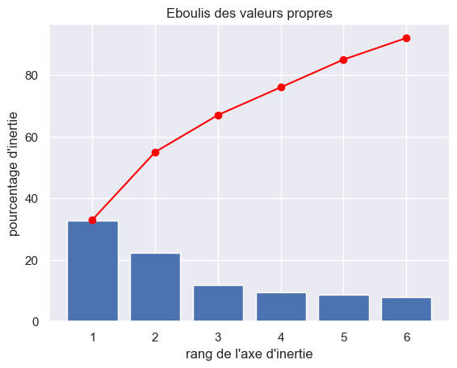

```python
plt.bar(x_list, scree)
plt.plot(x_list, scree_cum,c="red",marker='o')
plt.xlabel("rang de l'axe d'inertie")
plt.ylabel("pourcentage d'inertie")
plt.title("Eboulis des valeurs propres")
plt.show(block=False)
```

On a en bleu le pourcentage d'inertie ( la variance de chaque nouvelle composante) , et en rouge la variance cumulée.

### Combien de composantes faut-il retenir ?

Il y a plusieurs méthodes pour déterminer le nombre de composantes à retenir :

- critère du coude
- critère de la variance expliqué
- critère de Kaiser

Critère DU COUDE

On repère l’endroit à partir duquel le pourcentage d’inertie diminue beaucoup plus lentement lorsque l’on parcourt le diagramme des éboulis de gauche à droite.  
D'après le diagrame on voit que le pourcentage d'inertie diminue beaucoup plus lentement après la quatrième composante.  
*Donc on retient* **les composantes 1,2,3 et 4**

Critère DE KAISER

```python
# Affichage des valeurs propres de chaque composantes
pca.explained_variance_
```

```
array([3.62440227, 2.46397821, 1.30114228, 1.06001861, 0.95247269,
       0.86193619])
```

Le critère de Kaiser explique qu'il faut comparez chaque valeur propre à 1 et ensuite retenir uniquement les composantes principales dont les **valeurs propres sont supérieures à 1.**  
Nous allons retenir **les composantes 1,2,3 et 4**

#### Conclusion générale : nous retiendrons les composantes 1,2,3 et 4

### Etude des composantes

Intéressons nous maintenant à nos fameuses composantes. Nous avons dit dans le cours que c'est bien par un calcul que l'on obtient ces composantes.

La formule de ce calcul nous est donnée par l'attribut `components_`. Cette variable est généralement nommée `pcs` :

```python
pcs = pca.components_
pcs
```

```
array([[ 0.41170763,  0.41167599,  0.39889332,  0.28318403,  0.12244894,
         0.30992338,  0.38330602,  0.22999402,  0.07464872,  0.08595624,
         0.31286216],
       [-0.36766741, -0.36771436,  0.37307797,  0.44532543,  0.16193168,
        -0.1337314 ,  0.40754284, -0.35437932, -0.16810677,  0.14666603,
        -0.08094615],
       [ 0.05452571,  0.05444578,  0.13001549, -0.00431331, -0.55130716,
         0.36633429,  0.15578497, -0.3124658 ,  0.4134621 , -0.08541589,
        -0.48872176],
       [ 0.03265424,  0.03282722,  0.01132229, -0.3565554 ,  0.31206245,
         0.53876196, -0.14079405, -0.38472016, -0.27077334,  0.48935825,
        -0.04823331],
       [-0.09360262, -0.09352605, -0.01769141, -0.02047713,  0.05320863,
        -0.21191564, -0.02439564,  0.22985827,  0.61344955,  0.71010733,
        -0.00412009],
       [-0.13876365, -0.13866276,  0.13719879, -0.17337315,  0.63972671,
         0.1941186 , -0.01285397,  0.01043818,  0.49639014, -0.46124308,
        -0.07925094]])
```

Affichons la même chose mais version `pandas` :

```python
pcs = pd.DataFrame(pcs)
pcs
```

|  | 0 | 1 | 2 | 3 | 4 | 5 | 6 | 7 | 8 | 9 | 10 |
| --- | --- | --- | --- | --- | --- | --- | --- | --- | --- | --- | --- |
| 0 | 0.411708 | 0.411676 | 0.398893 | 0.283184 | 0.122449 | 0.309923 | 0.383306 | 0.229994 | 0.074649 | 0.085956 | 0.312862 |
| 1 | -0.367667 | -0.367714 | 0.373078 | 0.445325 | 0.161932 | -0.133731 | 0.407543 | -0.354379 | -0.168107 | 0.146666 | -0.080946 |
| 2 | 0.054526 | 0.054446 | 0.130015 | -0.004313 | -0.551307 | 0.366334 | 0.155785 | -0.312466 | 0.413462 | -0.085416 | -0.488722 |
| 3 | 0.032654 | 0.032827 | 0.011322 | -0.356555 | 0.312062 | 0.538762 | -0.140794 | -0.384720 | -0.270773 | 0.489358 | -0.048233 |
| 4 | -0.093603 | -0.093526 | -0.017691 | -0.020477 | 0.053209 | -0.211916 | -0.024396 | 0.229858 | 0.613450 | 0.710107 | -0.004120 |
| 5 | -0.138764 | -0.138663 | 0.137199 | -0.173373 | 0.639727 | 0.194119 | -0.012854 | 0.010438 | 0.496390 | -0.461243 | -0.079251 |

On remplace les numéros de colonnes par les libellés de notre dataframe d'analyse, nos features.

```python
pcs.columns = features
pcs.index = [f"F{i}" for i in x_list]
pcs.round(2)
```

|  | Population totale | pourcent_pop | Disponibilité intérieure | Exportations - Quantité | Importations - Quantité | Pertes | Production | Importations bilatérales | Taux de douane | Taux de chomage | Indice penetration |
| --- | --- | --- | --- | --- | --- | --- | --- | --- | --- | --- | --- |
| F1 | 0.41 | 0.41 | 0.40 | 0.28 | 0.12 | 0.31 | 0.38 | 0.23 | 0.07 | 0.09 | 0.31 |
| F2 | -0.37 | -0.37 | 0.37 | 0.45 | 0.16 | -0.13 | 0.41 | -0.35 | -0.17 | 0.15 | -0.08 |
| F3 | 0.05 | 0.05 | 0.13 | -0.00 | -0.55 | 0.37 | 0.16 | -0.31 | 0.41 | -0.09 | -0.49 |
| F4 | 0.03 | 0.03 | 0.01 | -0.36 | 0.31 | 0.54 | -0.14 | -0.38 | -0.27 | 0.49 | -0.05 |
| F5 | -0.09 | -0.09 | -0.02 | -0.02 | 0.05 | -0.21 | -0.02 | 0.23 | 0.61 | 0.71 | -0.00 |
| F6 | -0.14 | -0.14 | 0.14 | -0.17 | 0.64 | 0.19 | -0.01 | 0.01 | 0.50 | -0.46 | -0.08 |

```python
pcs.T
```

|  | F1 | F2 | F3 | F4 | F5 | F6 |
| --- | --- | --- | --- | --- | --- | --- |
| Population totale | 0.411708 | -0.367667 | 0.054526 | 0.032654 | -0.093603 | -0.138764 |
| pourcent_pop | 0.411676 | -0.367714 | 0.054446 | 0.032827 | -0.093526 | -0.138663 |
| Disponibilité intérieure | 0.398893 | 0.373078 | 0.130015 | 0.011322 | -0.017691 | 0.137199 |
| Exportations - Quantité | 0.283184 | 0.445325 | -0.004313 | -0.356555 | -0.020477 | -0.173373 |
| Importations - Quantité | 0.122449 | 0.161932 | -0.551307 | 0.312062 | 0.053209 | 0.639727 |
| Pertes | 0.309923 | -0.133731 | 0.366334 | 0.538762 | -0.211916 | 0.194119 |
| Production | 0.383306 | 0.407543 | 0.155785 | -0.140794 | -0.024396 | -0.012854 |
| Importations bilatérales | 0.229994 | -0.354379 | -0.312466 | -0.384720 | 0.229858 | 0.010438 |
| Taux de douane | 0.074649 | -0.168107 | 0.413462 | -0.270773 | 0.613450 | 0.496390 |
| Taux de chomage | 0.085956 | 0.146666 | -0.085416 | 0.489358 | 0.710107 | -0.461243 |
| Indice penetration | 0.312862 | -0.080946 | -0.488722 | -0.048233 | -0.004120 | -0.079251 |

Représentation des données en Heatmap

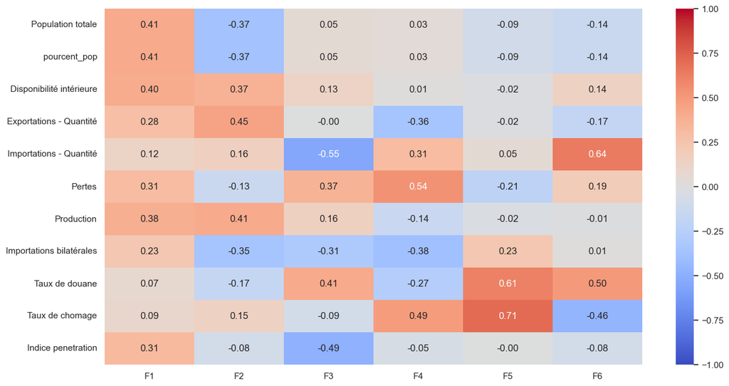

```python
fig, ax = plt.subplots(figsize=(15, 8))
sns.heatmap(pcs.T, vmin=-1, vmax=1, annot=True, cmap="coolwarm", fmt="0.2f")
```

## Cercles de corrélation

Définissons nos axes x et y. Nous allons utiliser les 2 premières composantes. Comme - en code - on commence à compter à partir de 0, cela nous donne :

```python
x, y = 0,1
```

Partie graphique

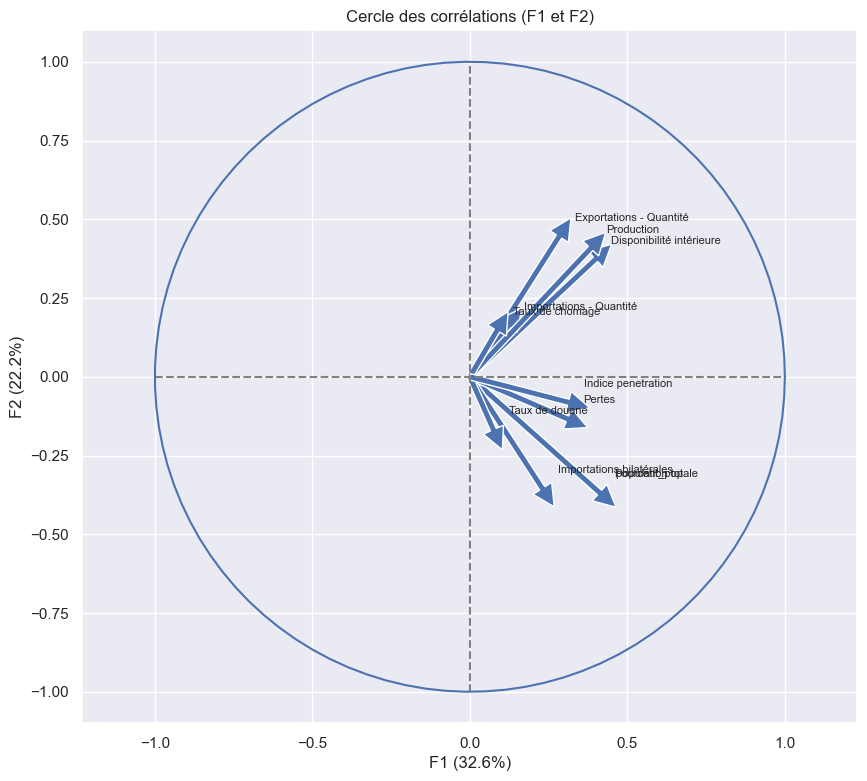

```python
fig, ax = plt.subplots(figsize=(10, 9))
for i in range(0, pca.components_.shape[1]):
    ax.arrow(0,
             0,  # Start the arrow at the origin
             pca.components_[0, i],  #0 for PC1
             pca.components_[1, i],  #1 for PC2
             head_width=0.07,
             head_length=0.07,
             width=0.02,              )

    plt.text(pca.components_[0, i] + 0.05,
             pca.components_[1, i] + 0.05,
             features[i],
             fontsize=8)

# affichage des lignes horizontales et verticales
plt.plot([-1, 1], [0, 0], color='grey', ls='--')
plt.plot([0, 0], [-1, 1], color='grey', ls='--')


# nom des axes, avec le pourcentage d'inertie expliqué
plt.xlabel('F{} ({}%)'.format(x+1, round(100*pca.explained_variance_ratio_[x],1)))
plt.ylabel('F{} ({}%)'.format(y+1, round(100*pca.explained_variance_ratio_[y],1)))

plt.title("Cercle des corrélations (F{} et F{})".format(x+1, y+1))


an = np.linspace(0, 2 * np.pi, 100)
plt.plot(np.cos(an), np.sin(an))  # Add a unit circle for scale
plt.axis('equal')
plt.show(block=False)
```

On peut en faire une fonction pour afficher le cercle de corrélation

```python
def correlation_graph(pca,
                      x_y,
                      features) :
    """Affiche le graphe des correlations

    Positional arguments :
    -----------------------------------
    pca : sklearn.decomposition.PCA : notre objet PCA qui a été fit
    x_y : list ou tuple : le couple x,y des plans à afficher, exemple [0,1] pour F1, F2
    features : list ou tuple : la liste des features (ie des dimensions) à représenter
    """

    # Extrait x et y
    x,y=x_y

    # Taille de l'image (en inches)
    fig, ax = plt.subplots(figsize=(10, 9))

    # Pour chaque composante :
    for i in range(0, pca.components_.shape[1]):

        # Les flèches
        ax.arrow(0,0,
                pca.components_[x, i],
                pca.components_[y, i],
                head_width=0.07,
                head_length=0.07,
                width=0.02, )

        # Les labels
        plt.text(pca.components_[x, i] + 0.05,
                pca.components_[y, i] + 0.05,
                features[i])

    # Affichage des lignes horizontales et verticales
    plt.plot([-1, 1], [0, 0], color='grey', ls='--')
    plt.plot([0, 0], [-1, 1], color='grey', ls='--')

    # Nom des axes, avec le pourcentage d'inertie expliqué
    plt.xlabel('F{} ({}%)'.format(x+1, round(100*pca.explained_variance_ratio_[x],1)))
    plt.ylabel('F{} ({}%)'.format(y+1, round(100*pca.explained_variance_ratio_[y],1)))

    # J'ai copié collé le code sans le lire
    plt.title("Cercle des corrélations (F{} et F{})".format(x+1, y+1))

    # Le cercle
    an = np.linspace(0, 2 * np.pi, 100)
    plt.plot(np.cos(an), np.sin(an))  # Add a unit circle for scale

    # Axes et display
    plt.axis('equal')
    plt.show(block=False)
```

On appelle la fonction pour F1 et F2

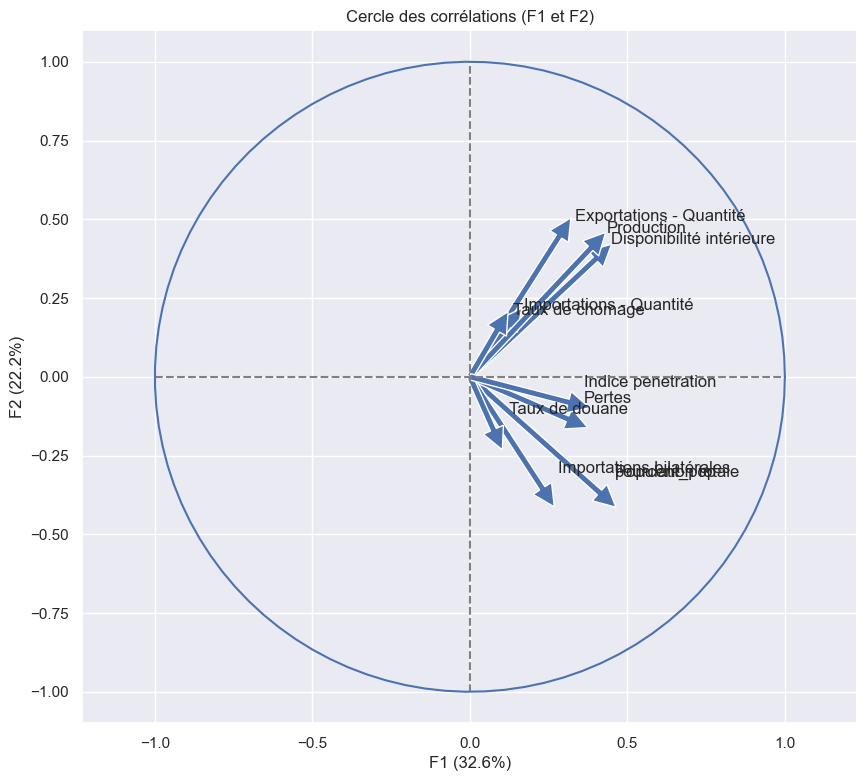

```python
x_y = (0,1)

correlation_graph(pca, x_y, features)
```

On appelle la fonction pour F3 et F4

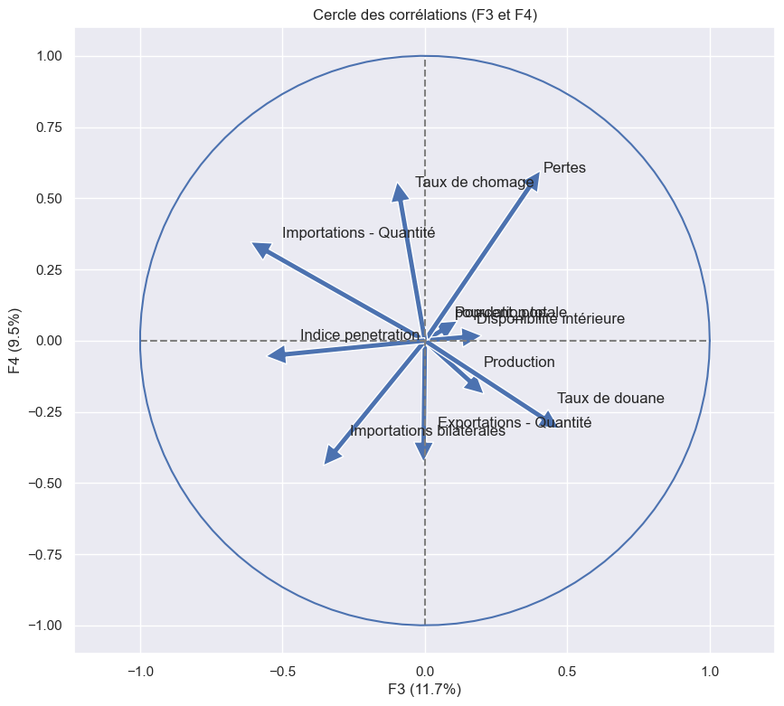

```python
correlation_graph(pca, (2,3), features)
```

- Les variables les plus corrélées à F3 sont : Importations, Indice pénétration, taux de douane (anti-corrélé)
- On peut confirmer l'explication = DEmande du pays en importations.
- Les variables les plus corrélées à F4 sont : Taux de chômage, pertes, exportations (anti corrélé), importations bilatérales (anti-corrélé)
- On peut confirmer l'explication = Situation économique du marché.

## Projection

Travaillons maintenant sur la projection de nos dimensions. Tout d'abord calculons les coordonnées de nos individus dans le nouvel espace :

```python
X_proj = pca.transform(X_scaled)
X_proj[:5]
```

```
array([[-8.97292262e-01, -1.63252492e-03, -1.21541875e-01,
         5.13800142e-01, -1.64136085e-03, -9.04830183e-01],
       [ 1.55139595e+00,  1.36442547e+00, -1.14547108e+00,
         2.51280852e+00,  2.05032425e+00,  1.06559569e-01],
       [-5.44245232e-01, -1.51553850e-01,  8.78507549e-01,
         3.42857776e-01,  1.68452092e+00, -2.72691276e-01],
       [ 2.11882390e+00,  1.52425690e+00, -3.63756722e+00,
         4.24904094e-01, -6.94627337e-01,  1.69170522e+00],
       [-5.67641536e-01,  4.43946422e-01, -8.85965341e-01,
         1.42934857e+00,  9.08163683e-01, -6.36130213e-01]])
```

```python
x_y
```

```
(0, 1)
```

Code de la fonction de projection de plan factoriel

```python
def display_factorial_planes(   X_projected,
                                x_y,
                                pca=None,
                                labels = None,
                                clusters=None,
                                alpha=1,
                                figsize=[10,8],
                                marker="." ):
    """
    Affiche la projection des individus

    Positional arguments :
    -------------------------------------
    X_projected : np.array, pd.DataFrame, list of list : la matrice des points projetés
    x_y : list ou tuple : le couple x,y des plans à afficher, exemple [0,1] pour F1, F2

    Optional arguments :
    -------------------------------------
    pca : sklearn.decomposition.PCA : un objet PCA qui a été fit, cela nous permettra d'afficher la variance de chaque composante, default = None
    labels : list ou tuple : les labels des individus à projeter, default = None
    clusters : list ou tuple : la liste des clusters auquel appartient chaque individu, default = None
    alpha : float in [0,1] : paramètre de transparence, 0=100% transparent, 1=0% transparent, default = 1
    figsize : list ou tuple : couple width, height qui définit la taille de la figure en inches, default = [10,8]
    marker : str : le type de marker utilisé pour représenter les individus, points croix etc etc, default = "."
    """

    # Transforme X_projected en np.array
    X_ = np.array(X_projected)

    # On définit la forme de la figure si elle n'a pas été donnée
    if not figsize:
        figsize = (7,6)

    # On gère les labels
    if  labels is None :
        labels = []
    try :
        len(labels)
    except Exception as e :
        raise e

    # On vérifie la variable axis
    if not len(x_y) ==2 :
        raise AttributeError("2 axes sont demandées")
    if max(x_y )>= X_.shape[1] :
        raise AttributeError("la variable axis n'est pas bonne")

    # on définit x et y
    x, y = x_y

    # Initialisation de la figure
    fig, ax = plt.subplots(1, 1, figsize=figsize)

    # On vérifie s'il y a des clusters ou non
    c = None if clusters is None else clusters

    # Les points
    # plt.scatter(   X_[:, x], X_[:, y], alpha=alpha,
    #                     c=c, cmap="Set1", marker=marker)
    sns.scatterplot(data=None, x=X_[:, x], y=X_[:, y], hue=c)

    # Si la variable pca a été fournie, on peut calculer le % de variance de chaque axe
    if pca :
        v1 = str(round(100*pca.explained_variance_ratio_[x]))  + " %"
        v2 = str(round(100*pca.explained_variance_ratio_[y]))  + " %"
    else :
        v1=v2= ''

    # Nom des axes, avec le pourcentage d'inertie expliqué
    ax.set_xlabel(f'F{x+1} {v1}')
    ax.set_ylabel(f'F{y+1} {v2}')

    # Valeur x max et y max
    x_max = np.abs(X_[:, x]).max() *1.1
    y_max = np.abs(X_[:, y]).max() *1.1

    # On borne x et y
    ax.set_xlim(left=-x_max, right=x_max)
    ax.set_ylim(bottom= -y_max, top=y_max)

    # Affichage des lignes horizontales et verticales
    plt.plot([-x_max, x_max], [0, 0], color='grey', alpha=0.8)
    plt.plot([0,0], [-y_max, y_max], color='grey', alpha=0.8)

    # Affichage des labels des points
    if len(labels) :
        # j'ai copié collé la fonction sans la lire
        for i,(_x,_y) in enumerate(X_[:,[x,y]]):
            plt.text(_x, _y+0.05, labels[i], fontsize='14', ha='center',va='center')

    # Titre et display
    plt.title(f"Projection des individus (sur F{x+1} et F{y+1})")
    plt.show()
```

On appelle la fonction de projection pour F1 et F2

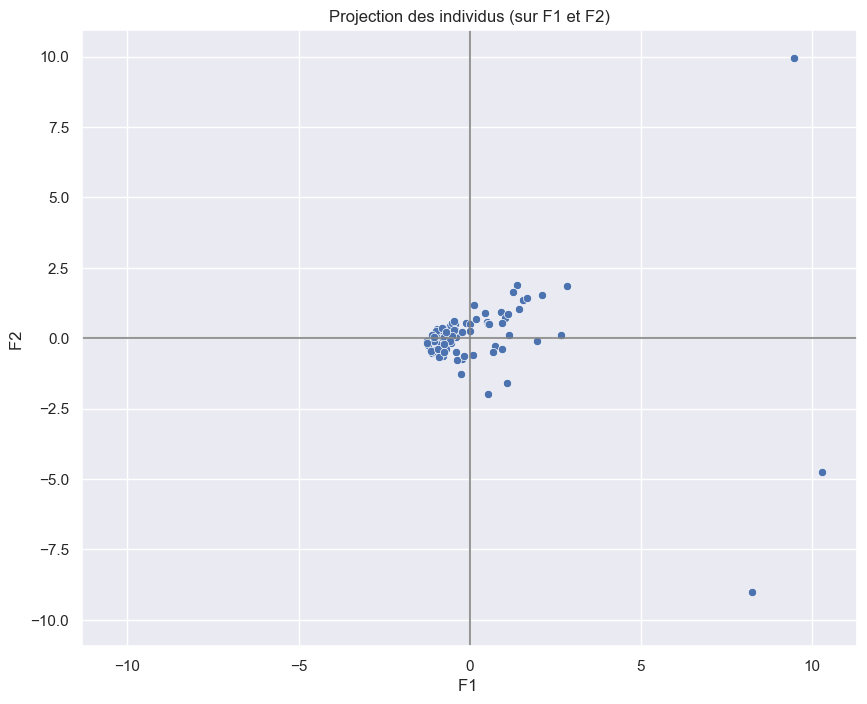

```python
x_y = [0,1]
display_factorial_planes(X_proj, x_y, clusters=None)
```

Appel de la fonction pour F1 et F2 avec plus de paramètres

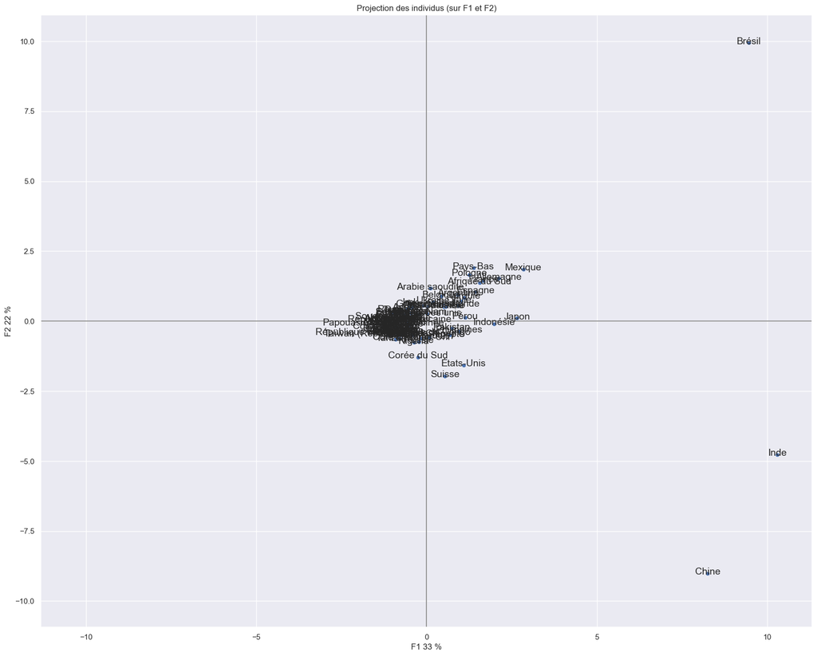

```python
x_y = [0,1]
display_factorial_planes(X_proj, x_y, pca, labels=pays, figsize=(20,16), clusters=None, marker="o")
```

Appel de la fonction pour F3 et F4 avec plus de paramètres

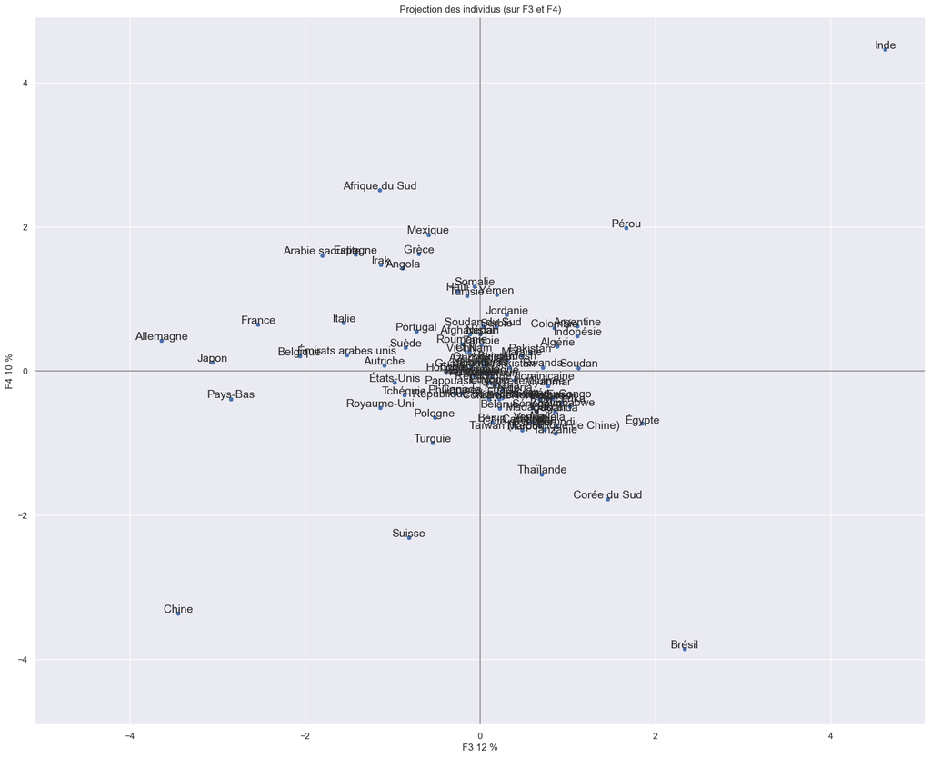

```python
x_y = [2,3]
display_factorial_planes(X_proj, x_y, pca, labels=pays, figsize=(20,16), clusters=None, marker="o")
```

# PARTIE 3 - CLUSTERING

### Importation des librairies pour e clustering.

```python
import pandas as pd
import numpy as np

import matplotlib.pyplot as plt
import seaborn as sns

from sklearn import datasets
from sklearn.cluster import AgglomerativeClustering
from sklearn import preprocessing
from sklearn.metrics import confusion_matrix

from scipy.cluster.hierarchy import dendrogram, linkage, fcluster, inconsistent
```

```python
from sklearn.cluster import KMeans
```

On charge SEABORN

```python
sns.set()
```

### Chargement des données de l'étude de marché

On charge et on trie le datframe d'analyse

```python
#On charge le fichier à analyser
data = pd.read_csv('OUT_merge_final_pour_ACP.csv', delimiter=',')
```

```python
# on trie par ordre alphabétique sur Zone
data = data.sort_values("Zone")
```

```python
data.shape
```

```
(100, 13)
```

On stocke les noms de pays dans une variable names

```python
names = data.Zone.values
#names[:10]
len(names)
```

```
100
```

On stocke les niveaux de revenus dans une variable themes

```python
themes = data.niveau_revenu.values
themes
```

```
array(['L', 'UM', 'UM', 'H', 'LM', 'H', 'H', 'H', 'H', 'UM', 'LM', 'H',
       'LM', 'UM', 'L', 'L', 'UM', 'L', 'LM', 'LM', 'H', 'H', 'UM', 'UM',
       'L', 'H', 'UM', 'LM', 'H', 'H', 'LM', 'H', 'UM', 'L', 'L', 'LM',
       'H', 'LM', 'LM', 'UM', 'UM', 'H', 'H', 'UM', 'UM', 'LM', 'L', 'UM',
       'L', 'L', 'LM', 'UM', 'L', 'LM', 'L', 'LM', 'L', 'L', 'LM', 'LM',
       'LM', 'H', 'LM', 'H', 'H', 'UM', 'UM', 'H', 'UM', 'L', 'UM', 'L',
       'UM', 'L', 'LM', 'L', 'LM', 'H', 'H', 'L', 'L', 'L', 'L', 'H', 'L',
       'H', 'UM', 'LM', 'UM', 'LM', 'UM', 'LM', 'L', 'LM', 'L', 'LM', 'H',
       'UM', 'H', 'L'], dtype=object)
```

```python
len(themes)
```

```
100
```

On stocke la matrice des données dans une variable X

```python
cols = ["Zone", "niveau_revenu"]
X = data.drop(columns=cols).values
X[:10]
```

```
array([[3.62961130e+07, 4.80862058e-01, 5.70000000e+04, 0.00000000e+00,
        2.90000000e+04, 2.00000000e+03, 2.80000000e+04, 0.00000000e+00,
        0.00000000e+00, 1.22300000e+01, 3.62294305e+00],
       [5.70097560e+07, 7.55282765e-01, 2.11800000e+06, 6.30000000e+04,
        5.14000000e+05, 8.30000000e+04, 1.66700000e+06, 4.68966663e+06,
        8.54000000e+00, 2.93266667e+01, 1.81771727e+01],
       [4.13891890e+07, 5.48336693e-01, 2.77000000e+05, 0.00000000e+00,
        2.00000000e+03, 1.30000000e+04, 2.75000000e+05, 0.00000000e+00,
        2.33900000e+01, 1.72146667e+01, 1.99424229e+00],
       [8.26584090e+07, 1.09508400e+00, 1.73900000e+06, 6.46000000e+05,
        8.42000000e+05, 0.00000000e+00, 1.51400000e+06, 0.00000000e+00,
        0.00000000e+00, 4.63800000e+00, 5.17502678e+01],
       [2.98167660e+07, 3.95021678e-01, 3.19000000e+05, 0.00000000e+00,
        2.77000000e+05, 2.00000000e+03, 4.20000000e+04, 2.04400378e+06,
        0.00000000e+00, 2.03563333e+01, 3.77923516e+00],
       [3.31011790e+07, 4.38534590e-01, 1.43500000e+06, 1.00000000e+04,
        7.22000000e+05, 0.00000000e+00, 6.16000000e+05, 0.00000000e+00,
        0.00000000e+00, 1.37913333e+01, 3.75808004e+00],
       [4.39371400e+07, 5.82092731e-01, 1.96200000e+06, 2.07000000e+05,
        8.00000000e+03, 1.06000000e+05, 2.16100000e+06, 6.14069300e+04,
        1.02800000e+01, 1.23883333e+01, 5.99012311e+00],
       [2.45846200e+07, 3.25704600e-01, 1.17100000e+06, 4.20000000e+04,
        1.60000000e+04, 0.00000000e+00, 1.26900000e+06, 1.31295974e+06,
        1.20000000e+00, 7.46500000e+00, 1.25517972e+01],
       [8.81990100e+06, 1.16848759e-01, 1.73000000e+05, 7.80000000e+04,
        1.10000000e+05, 0.00000000e+00, 1.48000000e+05, 0.00000000e+00,
        0.00000000e+00, 6.83433333e+00, 2.58810232e+01],
       [9.84532000e+06, 1.30433825e-01, 1.29000000e+05, 0.00000000e+00,
        2.70000000e+04, 0.00000000e+00, 1.04000000e+05, 0.00000000e+00,
        0.00000000e+00, 7.08566667e+00, 2.46979138e+00]])
```

### Scaling des données

```python
# Instanciation de sclaer
std_scale = preprocessing.StandardScaler()

# Entrainement
std_scale.fit(X)

# Transformation des données
X_scaled = std_scale.transform(X)
X_scaled[:10]
```

```
array([[-0.18786646, -0.18786646, -0.47488126, -0.2533386 , -0.37265581,
        -0.2498784 , -0.4104352 , -0.22616245, -0.80048819,  0.63028281,
        -0.45764914],
       [-0.08156343, -0.08156343,  1.20292289, -0.11825327,  1.97581178,
         0.77286796,  0.6360526 , -0.06033827, -0.0700424 ,  3.08037892,
         0.64076011],
       [-0.16172864, -0.16172864, -0.29578523, -0.2533386 , -0.50339524,
        -0.11098692, -0.25272776, -0.22616245,  1.20011217,  1.34462746,
        -0.58056736],
       [ 0.0500662 ,  0.0500662 ,  0.89438928,  1.13182211,  3.56405378,
        -0.2751314 ,  0.53836338, -0.22616245, -0.80048819, -0.45771464,
         3.17452515],
       [-0.22111866, -0.22111866, -0.26159417, -0.2533386 ,  0.8282101 ,
        -0.2498784 , -0.40149631, -0.15388754, -0.80048819,  1.79485472,
        -0.44585376],
       [-0.20426295, -0.20426295,  0.64691113, -0.23189649,  2.98298964,
        -0.2751314 , -0.03500211, -0.22616245, -0.80048819,  0.854035  ,
        -0.44745034],
       [-0.14865248, -0.14865248,  1.07592752,  0.1905132 , -0.47434203,
         1.06327742,  0.95146747, -0.22399113,  0.0787838 ,  0.65297331,
        -0.27899781],
       [-0.24797018, -0.24797018,  0.4319959 , -0.16328172, -0.43560442,
        -0.2751314 ,  0.38193293, -0.17973687, -0.69784943, -0.05258177,
         0.21621243],
       [-0.32887518, -0.32887518, -0.38044881, -0.0860901 ,  0.01956249,
        -0.2751314 , -0.3338162 , -0.22616245, -0.80048819, -0.1429616 ,
         1.22217052],
       [-0.3236127 , -0.3236127 , -0.41626801, -0.2533386 , -0.38234021,
        -0.2751314 , -0.36190983, -0.22616245, -0.80048819, -0.10694342,
        -0.54467762]])
```

```python
# avec la méthde describe on s'assure que la moyenne de chaque dimension est à 0, et l'écart-type est de 1
idx = ["mean", "std"]

pd.DataFrame(X_scaled).describe().round(2).loc[idx, :]
```

|  | 0 | 1 | 2 | 3 | 4 | 5 | 6 | 7 | 8 | 9 | 10 |
| --- | --- | --- | --- | --- | --- | --- | --- | --- | --- | --- | --- |
| mean | -0.00 | 0.00 | 0.00 | -0.00 | 0.00 | -0.00 | -0.00 | 0.00 | 0.00 | -0.00 | 0.00 |
| std | 1.01 | 1.01 | 1.01 | 1.01 | 1.01 | 1.01 | 1.01 | 1.01 | 1.01 | 1.01 | 1.01 |

### Linkage

La fonction linkage de scipy.cluster.hierarchy est utilisée pour calculer la matrice de liaison. La méthode ward est souvent utilisée pour minimiser la variance intra-cluster.

```python
Z = linkage(X_scaled, method="ward")
Z[:10]
```

```
array([[2.40000000e+01, 7.90000000e+01, 6.04874502e-02, 2.00000000e+00],
       [1.90000000e+01, 5.20000000e+01, 1.25103126e-01, 2.00000000e+00],
       [9.00000000e+00, 3.50000000e+01, 1.28324981e-01, 2.00000000e+00],
       [5.40000000e+01, 8.30000000e+01, 1.29855279e-01, 2.00000000e+00],
       [1.40000000e+01, 4.80000000e+01, 1.61538863e-01, 2.00000000e+00],
       [4.60000000e+01, 4.90000000e+01, 1.96513686e-01, 2.00000000e+00],
       [0.00000000e+00, 5.60000000e+01, 2.00508191e-01, 2.00000000e+00],
       [1.20000000e+01, 9.00000000e+01, 2.02957217e-01, 2.00000000e+00],
       [8.40000000e+01, 1.00000000e+02, 2.05746185e-01, 3.00000000e+00],
       [4.50000000e+01, 5.70000000e+01, 2.27324301e-01, 2.00000000e+00]])
```

### Dendogramme

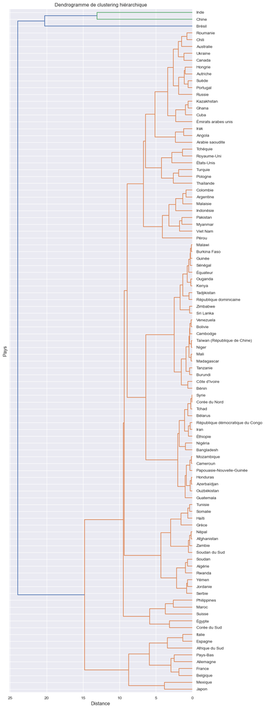

```python
fig, ax = plt.subplots(1, 1, figsize=(8,30))

_ = dendrogram(Z, ax=ax, labels=names, orientation = "left")

plt.title("Dendrogramme de clustering hiérarchique")
ax.set_xlabel("Distance")
ax.set_ylabel("Pays")
ax.tick_params(axis='x', which='major', labelsize=10)
ax.tick_params(axis='y', which='major', labelsize=10)
```

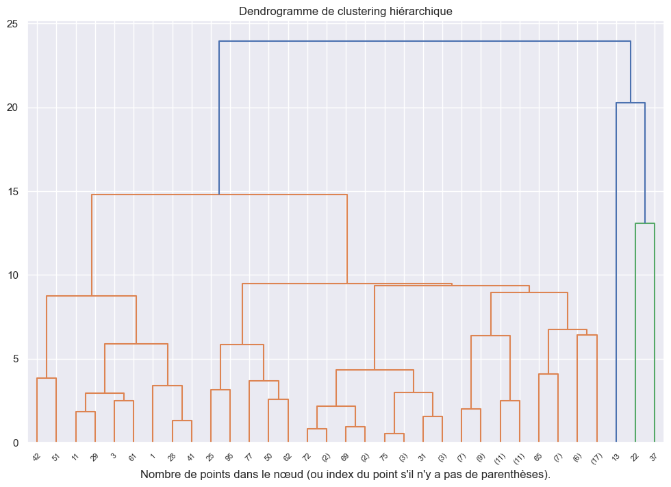

```python
fig, ax = plt.subplots(1, 1, figsize=(12,8))

_ = dendrogram(Z,  p=6, truncate_mode="level", ax=ax)

plt.title("Dendrogramme de clustering hiérarchique")
plt.xlabel("Nombre de points dans le nœud (ou index du point s'il n'y a pas de parenthèses).")
plt.show()
```

### Clusters

```python
# On définit le nmbre de cluster souhaités (max le nb de dimensions du df data )
k=10

# on applique la fonction fclusters() de spicy pour définir les clusters
clusters = fcluster(Z, k, criterion='maxclust')
#clusters = fcluster(Z, k, criterion='maxclust_monocrit', monocrit=inconsistent_values[2]) # or use a different index for inconsistent_values
clusters
```

```
array([ 4,  2,  4,  2,  7,  7,  6,  7,  7,  5,  5,  2,  5, 10,  5,  5,  5,
        5,  5,  5,  7,  7,  8,  6,  5,  3,  7,  5,  2,  2,  7,  4,  5,  5,
        4,  5,  7,  9,  6,  7,  5,  2,  1,  4,  7,  5,  5,  6,  5,  5,  3,
        1,  5,  6,  5,  5,  4,  5,  5,  6,  5,  2,  3,  7,  7,  6,  7,  7,
        7,  4,  5,  5,  4,  4,  4,  4,  5,  3,  7,  5,  5,  5,  5,  5,  5,
        7,  7,  4,  7,  7,  5,  6,  4,  4,  5,  3,  7,  5,  7,  5],
      dtype=int32)
```

```python
len(clusters)
```

```
100
```

### Table de contingence pour l'analyse

```python
crosstab = pd.crosstab(themes, clusters, dropna=False)
crosstab.rename_axis(columns="Cluster", index="Niv-revenu", inplace=True)
crosstab
```

| Cluster Niv-revenu | 1 | 2 | 3 | 4 | 5 | 6 | 7 | 8 | 9 | 10 |
| --- | --- | --- | --- | --- | --- | --- | --- | --- | --- | --- |
| H | 1 | 6 | 2 | 1 | 1 | 1 | 13 | 0 | 0 | 0 |
| L | 0 | 0 | 0 | 7 | 19 | 0 | 0 | 0 | 0 | 0 |
| LM | 0 | 0 | 3 | 3 | 11 | 4 | 3 | 0 | 1 | 0 |
| UM | 1 | 1 | 0 | 3 | 7 | 3 | 7 | 1 | 0 | 1 |

```python
# Afficher toutes les colormaps disponibles
plt.cm.datad.keys()
```

```
dict_keys(['Blues', 'BrBG', 'BuGn', 'BuPu', 'CMRmap', 'GnBu', 'Greens', 'Greys', 'OrRd', 'Oranges', 'PRGn', 'PiYG', 'PuBu', 'PuBuGn', 'PuOr', 'PuRd', 'Purples', 'RdBu', 'RdGy', 'RdPu', 'RdYlBu', 'RdYlGn', 'Reds', 'Spectral', 'Wistia', 'YlGn', 'YlGnBu', 'YlOrBr', 'YlOrRd', 'afmhot', 'autumn', 'binary…
```

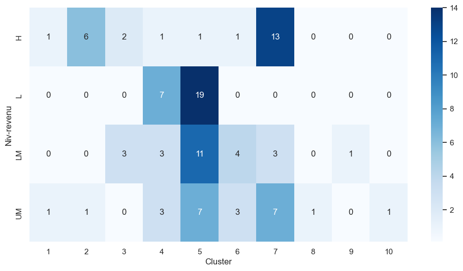

```python
fig, ax = plt.subplots(1,1, figsize=(12,6))
ax = sns.heatmap(crosstab, vmin=0.1, vmax=14, annot=True, cmap="Blues")
```

On affiche les pays de chaque cluster

```python
# Liste des cluster
liste_clust = pd.DataFrame({"name" : names, "theme" : themes, "cluster" : clusters})
liste_clust.head()
```

|  | name | theme | cluster |
| --- | --- | --- | --- |
| 0 | Afghanistan | L | 4 |
| 1 | Afrique du Sud | UM | 2 |
| 2 | Algérie | UM | 4 |
| 3 | Allemagne | H | 2 |
| 4 | Angola | LM | 7 |

```python
for i in range(1, 13) :
    # on fait une selection
    sub_df = liste_clust.loc[liste_clust.cluster == i]

    # le cluster en question
    print(f"cluster : {i}")

    # on extrait les noms et les themes de chaque ligne
    names_list = sub_df.name.values
    themes_list = sub_df.theme.values

    # on créé une liste de couple nom/theme
    ziped = zip(names_list, themes_list)
    txt = [f"{n} ({t})" for n, t in ziped]

    # on transforme en str
    txt = " / ".join(txt)

    # on print
    print(txt)
    print("\n\n")
```

[output not shown]

## Kmeans pour déterminer le nombre de cluster à retenir.

```python
data.head()
```

|  | Zone | Population totale | pourcent_pop | Disponibilité intérieure | Exportations - Quantité | Importations - Quantité | Pertes | Production | Importations bilatérales | Taux de douane | Taux de chomage | Indice penetration | niveau_revenu |
| --- | --- | --- | --- | --- | --- | --- | --- | --- | --- | --- | --- | --- | --- |
| 0 | Afghanistan | 36296113.0 | 0.480862 | 57000.0 | 0.0 | 29000.0 | 2000.0 | 28000.0 | 0.000000e+00 | 0.00 | 12.230000 | 3.622943 | L |
| 1 | Afrique du Sud | 57009756.0 | 0.755283 | 2118000.0 | 63000.0 | 514000.0 | 83000.0 | 1667000.0 | 4.689667e+06 | 8.54 | 29.326667 | 18.177173 | UM |
| 2 | Algérie | 41389189.0 | 0.548337 | 277000.0 | 0.0 | 2000.0 | 13000.0 | 275000.0 | 0.000000e+00 | 23.39 | 17.214667 | 1.994242 | UM |
| 3 | Allemagne | 82658409.0 | 1.095084 | 1739000.0 | 646000.0 | 842000.0 | 0.0 | 1514000.0 | 0.000000e+00 | 0.00 | 4.638000 | 51.750268 | H |
| 4 | Angola | 29816766.0 | 0.395022 | 319000.0 | 0.0 | 277000.0 | 2000.0 | 42000.0 | 2.044004e+06 | 0.00 | 20.356333 | 3.779235 | LM |

[output not shown]

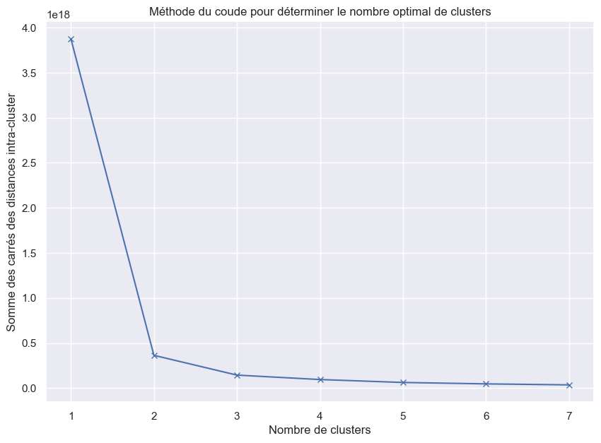

```python
# Calculer la somme des carrés des distances intra-cluster pour différents nombres de clusters
inertia = []
K = range(1, 8)  # Essayez de 1 à 8 clusters comme vu précédement

for k in K:
    kmeans = KMeans(n_clusters=k, random_state=42)
    kmeans.fit(X)
    inertia.append(kmeans.inertia_)

# Tracer la courbe du coude
plt.figure(figsize=(10, 7))
plt.plot(K, inertia, 'bx-')
plt.xlabel('Nombre de clusters')
plt.ylabel('Somme des carrés des distances intra-cluster')
plt.title('Méthode du coude pour déterminer le nombre optimal de clusters')
plt.show()
```